# Vintage Methods for Model Selection

### Forward Selection

- **Step 1:** We fit each of the one-predictor models and measure the performance of each model using the criteria/metric chosen. The predictor from the model that has the best performance is retained.
- **Step 2:** We then fit each of the two-predictor models that can be fitted with the predictor retained in Step 1. The predictors from the model that has the best performance are retained.

We continue this process until we have either (a) fitted a model with all the predictors, or (b) hit some stopping/selection criteria that we have identified (e.g., stop once one of the *p*-values is greater than 0.05).

**IMPORTANT**

Once a predictor is retained in forward selection, it is always included in all later stages.

In our example, we will employ forward selection to adopt a model using the following performance metric and selection criteria:

- **Metric of Performance:** Select the predictor with the highest *t*-value (absolute value).
- **Selection Criterion:** All *t*-values for predictors in the model need to be greater than 1.

```r
# Step 1: Fit all one-predictor models
# tidy(lm(life_expectancy ~ -1 + population, data = z_usa)) #t = 1.63
# tidy(lm(life_expectancy ~ -1 + income,     data = z_usa)) #t = 4.09
# tidy(lm(life_expectancy ~ -1 + illiteracy, data = z_usa)) #t = -0.45
# tidy(lm(life_expectancy ~ -1 + murder,     data = z_usa)) #t = -2.93
# tidy(lm(life_expectancy ~ -1 + hs_grad,    data = z_usa)) #t = 2.47
# tidy(lm(life_expectancy ~ -1 + frost,      data = z_usa)) #t = 1.19
# tidy(lm(life_expectancy ~ -1 + area,       data = z_usa)) #t = 0.38
```

The best one-predictor model under this criterion includes income.

```r
# Step 2: Fit all two-predictor models that include income
# tidy(lm(life_expectancy ~ -1 + income + population, data = z_usa)) #t = 1.71
# tidy(lm(life_expectancy ~ -1 + income + illiteracy, data = z_usa)) #t = -0.58
# tidy(lm(life_expectancy ~ -1 + income + murder,     data = z_usa)) #t = -1.37
# tidy(lm(life_expectancy ~ -1 + income + hs_grad,    data = z_usa)) #t = 0.46
# tidy(lm(life_expectancy ~ -1 + income + frost,      data = z_usa)) #t = 0.03
# tidy(lm(life_expectancy ~ -1 + income + area,       data = z_usa)) #t = 0.51
```

The best two-predictor model under this criterion includes income and population.

```r
# Step 3: Fit all three-predictor models that include income and population
# tidy(lm(life_expectancy ~ -1 + income + population + illiteracy, data = z_usa)) #t = -2.13
# tidy(lm(life_expectancy ~ -1 + income + population + murder,     data = z_usa)) #t = -1.54
# tidy(lm(life_expectancy ~ -1 + income + population + hs_grad,    data = z_usa)) #t = 1.50
# tidy(lm(life_expectancy ~ -1 + income + population + frost,      data = z_usa)) #t = 0.90
# tidy(lm(life_expectancy ~ -1 + income + population + area,       data = z_usa)) #t = 0.25
```

The best three-predictor model under this criterion includes income, population, and illiteracy.

```r
# Step 4: Fit all four-predictor models that include income, population, and illiteracy
# tidy(lm(life_expectancy ~ -1 + income + population + illiteracy + murder,  data = z_usa)) #t = -1.08
# tidy(lm(life_expectancy ~ -1 + income + population + illiteracy + hs_grad, data = z_usa)) #t = 0.45
# tidy(lm(life_expectancy ~ -1 + income + population + illiteracy + frost,   data = z_usa)) #t = -0.35
# tidy(lm(life_expectancy ~ -1 + income + population + illiteracy + area,    data = z_usa)) #t = 0.13
```

The best four-predictor model under this criterion includes income, population, illiteracy, and murder rate. Continue this process to determine the best four-, five-, six- and seven-predictor models

```r
# Step 5: Fit all five-predictor models that include income, population, illiteracy, and murder_rate
# tidy(lm(life_expectancy ~ -1 + income + population + illiteracy + murder + hs_grad, data = z_usa)) #t = -0.31
# tidy(lm(life_expectancy ~ -1 + income + population + illiteracy + murder + frost,   data = z_usa)) #t = -0.77
# tidy(lm(life_expectancy ~ -1 + income + population + illiteracy + murder + area,    data = z_usa)) #t = 0.21

# Step 6: Fit all six-predictor models that include income, population, illiteracy, murder_rate, and frost
# tidy(lm(life_expectancy ~ -1 + income + population + illiteracy + murder + frost + hs_grad, data = z_usa)) #t = -0.12
# tidy(lm(life_expectancy ~ -1 + income + population + illiteracy + murder + frost + area,    data = z_usa)) #t = 0.62

# Step 7: Fit all seven-predictor models that include income, population, illiteracy, murder_rate, frost, and area
# tidy(lm(life_expectancy ~ -1 + income + population + illiteracy + murder + frost + area + hs_grad, data = z_usa)) #t = -0.27
```

At each stage we could also check to see that all the predictors in the selected model meet our selection criterion that the *t*-value for all predictors is greater than 1. With this criteria we could have stopped after Stage 4 since not all of the *t*-values of the best model in Stage 5 were above 1. Based on the forward selection process and the criteria we adopted, we would adopt the best performing model from Stage 4.

```r
# Model adopted from forward selection
tidy(lm(life_expectancy ~ -1 + income + population + illiteracy + murder,  data = z_usa))
```

```
# A tibble: 4 × 5
  term       estimate std.error statistic p.value
  <chr>         <dbl>     <dbl>     <dbl>   <dbl>
1 income        0.418     0.132      3.18 0.00259
2 population    0.378     0.146      2.60 0.0123
3 illiteracy   -0.270     0.149     -1.80 0.0775
4 murder       -0.146     0.135     -1.08 0.284
```

$$\begin{split}
\widehat{\mathrm{Life~Expectancy}_i} = &0.42(\mathrm{Income}_i) + 0.38(\mathrm{Population}_i) - 0.27(\mathrm{Illiteracy~Rate}_i)\\
&- 0.15(\mathrm{Murder~Rate}_i)
\end{split}$$

where all the variables in the equation are standardized. Note that the *p*-values are irrelevant as that did not factor into our selection criteria. (In fact, I would not even report them if I was using this selection criterion.)

### Backward Elimination

- **Step 1:** We begin with a model that includes all of the predictors.
- **Step 2:** We then fit each of the models that include all of the predictors except one, and measure the performance. The predictor that decreases the performance the least is removed from the model.

We continue this process, at each stage removing the predictor that has the least impact on performance until we get down to an intercept-only model.

**IMPORTANT**

Once a predictor is removed, it is removed in all later stages.

In our example, we will employ backward elimination to adopt a model using the following performance metric and selection criteria:

- **Metric of Performance:** Select the model with the highest $R^2$ value.
- **Selection Criterion:** The total $R^2$ value needs to be greater than 0.3.

```r
# Step 0: Fit model with all predictors
# glance(lm(life_expectancy ~ . - 1, data = z_usa))$r.squared #R2 = 0.379

# Step 1: Fit all models with one predictor removed
# glance(lm(life_expectancy ~ . -1 - population, data = z_usa))$r.squared #R2 = 0.319
# glance(lm(life_expectancy ~ . -1 - income,     data = z_usa))$r.squared #R2 = 0.264
# glance(lm(life_expectancy ~ . -1 - illiteracy, data = z_usa))$r.squared #R2 = 0.328
# glance(lm(life_expectancy ~ . -1 - murder,     data = z_usa))$r.squared #R2 = 0.357
# glance(lm(life_expectancy ~ . -1 - hs_grad,    data = z_usa))$r.squared #R2 = 0.378
# glance(lm(life_expectancy ~ . -1 - frost,      data = z_usa))$r.squared #R2 = 0.367
# glance(lm(life_expectancy ~ . -1 - area,       data = z_usa))$r.squared #R2 = 0.373
```

After Step 1, the model with the highest $R^2$ removes high school graduation rate. Since the $R^2$ value is above our threshold of 0.3, we continue to Step 2.

```r
# Step 2: Fit all models with hs_grad and one other predictor removed
# glance(lm(life_expectancy ~ . -1 - hs_grad - population, data = z_usa))$r.squared #R2 = 0.309
# glance(lm(life_expectancy ~ . -1 - hs_grad - income,     data = z_usa))$r.squared #R2 = 0.232
# glance(lm(life_expectancy ~ . -1 - hs_grad - illiteracy, data = z_usa))$r.squared #R2 = 0.324
# glance(lm(life_expectancy ~ . -1 - hs_grad - murder,     data = z_usa))$r.squared #R2 = 0.352
# glance(lm(life_expectancy ~ . -1 - hs_grad - frost,      data = z_usa))$r.squared #R2 = 0.366
# glance(lm(life_expectancy ~ . -1 - hs_grad - area,       data = z_usa))$r.squared #R2 = 0.373
```

After Step 2, the model with the highest $R^2$ removes high school graduation rate and area. Since the $R^2$ value is above our threshold of 0.3, we continue to Step 3. We will continue this process to determine the best four-, three-, two- and one-predictor models. At each stage we should also check to see that the selected model does not decrease the criteria beyond our pre-identified threshold of 0.3.

```r
# Step 3: Fit all models with hs_grad, area, and one other predictor removed
# glance(lm(life_expectancy ~ . -1 - hs_grad - area - population, data = z_usa))$r.squared #R2 = 0.289
# glance(lm(life_expectancy ~ . -1 - hs_grad - area - income,     data = z_usa))$r.squared #R2 = 0.232
# glance(lm(life_expectancy ~ . -1 - hs_grad - area - illiteracy, data = z_usa))$r.squared #R2 = 0.323
# glance(lm(life_expectancy ~ . -1 - hs_grad - area - murder,     data = z_usa))$r.squared #R2 = 0.351
# glance(lm(life_expectancy ~ . -1 - hs_grad - area - frost,      data = z_usa))$r.squared #R2 = 0.365

# Step 4: Fit all models with hs_grad, area, frost, and one other predictor removed
# glance(lm(life_expectancy ~ . -1 - hs_grad - area - frost - population, data = z_usa))$r.squared #R2 = 0.276
# glance(lm(life_expectancy ~ . -1 - hs_grad - area - frost - income,     data = z_usa))$r.squared #R2 = 0.231
# glance(lm(life_expectancy ~ . -1 - hs_grad - area - frost - illiteracy, data = z_usa))$r.squared #R2 = 0.322
# glance(lm(life_expectancy ~ . -1 - hs_grad - area - frost - murder,     data = z_usa))$r.squared #R2 = 0.350

# Step 5: Fit all models with hs_grad, area, frost, murder, and one other predictor removed
# glance(lm(life_expectancy ~ . -1 - hs_grad - area - frost - murder - population, data = z_usa))$r.squared #R2 = 0.253
# glance(lm(life_expectancy ~ . -1 - hs_grad - area - frost - murder - income,     data = z_usa))$r.squared #R2 = 0.112
# glance(lm(life_expectancy ~ . -1 - hs_grad - area - frost - murder - illiteracy, data = z_usa))$r.squared #R2 = 0.289
```

With this criteria we stop after Step 4 since the $R^2$ value of the best model in Step 5 has an $R^2$ value that is less than 0.3.

```r
# Adopted backward elimination model
tidy(lm(life_expectancy ~ . -1 - hs_grad - area - frost - murder, data = z_usa))
```

```
# A tibble: 3 × 5
  term       estimate std.error statistic  p.value
  <chr>         <dbl>     <dbl>     <dbl>    <dbl>
1 population    0.392     0.145      2.70 0.00944
2 income        0.488     0.115      4.23 0.000102
3 illiteracy   -0.310     0.145     -2.13 0.0379
```

### Stepwise Regression

Stepwise regression is based on backward elimination (starting with all predictors and eliminating them one at a time), but the predictors that were removed in earlier steps can be considered for re-entry into the model at later stages. Using the following criteria:

- **Metric of Performance:** Select the predictor with the highest *p*-value for removal.
- **Selection Criterion:** Predictors with *p*-values greater than 0.3 are candidates for elimination; and those with *p*-values less than 0.1 are candidates for re-entry.

Based on the results of this analysis (not shown), the adopted model is:

$$\widehat{\mathrm{Life~Expectancy}_i} = 0.39(\mathrm{Population}_i) + 0.49(\mathrm{Income}_i) - 0.31(\mathrm{Illiteracy~Rate}_i)$$

## Using R for Automated Model Building

Functions from the `{olsrr}` package perform automated forward selection, backward elimination, and stepwise regression. The evaluation metrics that these functions use include the *p*-value, $R^2$, Adjusted $R^2$, AIC, BIC, and SBIC. All of the functions require a `lm()` object that includes all possible predictors.

While we can’t mimic our forward selection from earlier (the *t*-value is not a metric we can use with this package), we demonstrate forward selction using the AIC. Variables are added one-at-a-time based on their AIC values. The process terminates when either all the variables have been added or the addition of another variable increases the AIC value.

```r
library(olsrr)

# Forward selection using AIC
fs_output = ols_step_forward_aic(lm.all, details = TRUE)
```

```
Forward Selection Method
------------------------

Candidate Terms:

1. population
2. income
3. illiteracy
4. murder
5. hs_grad
6. frost
7. area


Step     => 0
Model    => life_expectancy ~ 1
AIC      => 209.8146

Initiating stepwise selection...

                      Table: Adding New Variables
-----------------------------------------------------------------------
Predictor     DF      AIC        SBC       SBIC       R2       Adj. R2
-----------------------------------------------------------------------
income         1    197.033    202.886    49.362    0.24743     0.23238
murder         1    203.710    209.564    55.531    0.14431     0.12720
hs_grad        1    205.929    211.783    57.583    0.10702     0.08916
population     1    209.174    215.028    60.589    0.04952     0.03051
frost          1    210.386    216.240    61.713    0.02710     0.00764
illiteracy     1    211.607    217.460    62.846    0.00399    -0.01593
area           1    211.668    217.522    62.903    0.00282    -0.01713
-----------------------------------------------------------------------

Step     => 1
Added    => income
Model    => life_expectancy ~ income
AIC      => 197.0327

                     Table: Adding New Variables
----------------------------------------------------------------------
```

[output cut: 34 more lines]

```
---------------------------------------------------------------------
murder        1    194.200    205.907    48.138    0.36500    0.31096
hs_grad       1    195.238    206.946    48.962    0.35219    0.29706
frost         1    195.324    207.032    49.030    0.35112    0.29589
area          1    195.439    207.147    49.121    0.34968    0.29434
---------------------------------------------------------------------


No more variables to be added.

Variables Selected:

=> income
=> population
=> illiteracy
```

```r
# View results from adopted model
fs_output
```

```
                             Stepwise Summary
------------------------------------------------------------------------
Step    Variable        AIC        SBC       SBIC       R2       Adj. R2
------------------------------------------------------------------------
 0      Base Model    209.815    213.717    61.571    0.00000    0.00000
 1      income        197.033    202.886    49.362    0.24743    0.23238
 2      population    196.078    203.883    48.699    0.28901    0.25999
 3      illiteracy    193.457    203.214    46.879    0.34946    0.30880
------------------------------------------------------------------------

Final Model Output
------------------

                         Model Summary
---------------------------------------------------------------
R                       0.591       RMSE                 1.412
R-Squared               0.349       MSE                  1.994
Adj. R-Squared          0.309       Coef. Var            1.867
Pred R-Squared          0.181       AIC                193.457
MAE                     1.120       SBC                203.214
---------------------------------------------------------------
 RMSE: Root Mean Square Error
 MSE: Mean Square Error
 MAE: Mean Absolute Error
 AIC: Akaike Information Criteria
 SBC: Schwarz Bayesian Criteria

                              ANOVA
------------------------------------------------------------------
               Sum of
              Squares        DF    Mean Square      F        Sig.
------------------------------------------------------------------
Regression     55.699         3         18.566    8.595    0.0001
Residual      103.689        48          2.160
Total         159.388        51
------------------------------------------------------------------

                                  Parameter Estimates
----------------------------------------------------------------------------------------
      model      Beta    Std. Error    Std. Beta      t        Sig      lower     upper
----------------------------------------------------------------------------------------
(Intercept)    74.975         1.269                 59.104    0.000    72.424    77.525
     income     0.162         0.039        0.488     4.186    0.000     0.084     0.240
 population     0.095         0.036        0.392     2.674    0.010     0.024     0.166
 illiteracy    -0.127         0.060       -0.310    -2.112    0.040    -0.247    -0.006
----------------------------------------------------------------------------------------
```

We can also plot the AIC values versus each step of the selction process.

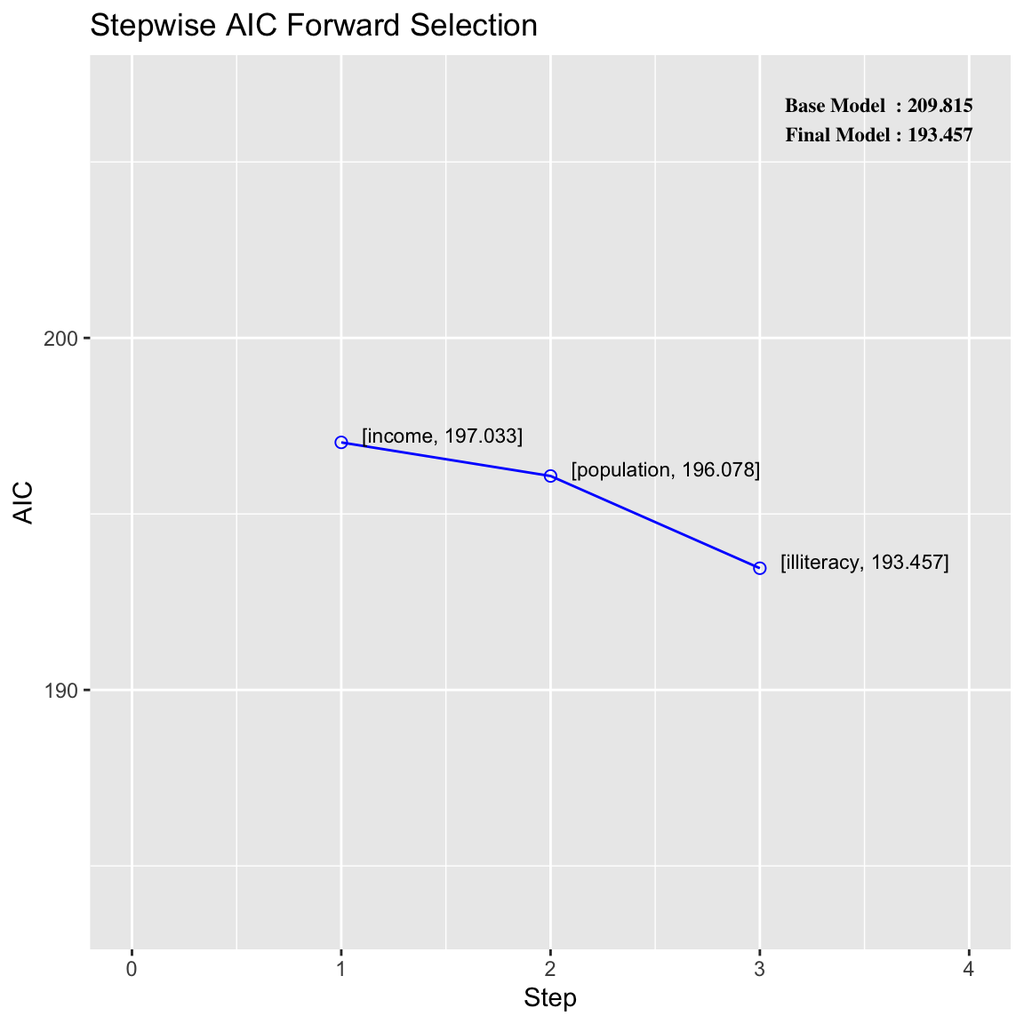

Figure 1: Plot of the AIC versus each step in the forward selection process.

```r
plot(fs_output)
```

Backward elimination and stepwise regression operate in a similar manner. For backward elimination the function using AIC would be `ols_step_backward_aic()`. For stepwise regression the function would be `ols_step_both_aic()`.

## All Subsets Regression

All subsets regression fits **all possible *k*-predictor models**. The number of *k*-predictor models is:

$$\mathrm{Number~of~Models} = 2^p - 1$$

where *p* is the number of predictors in the candidate set.

The `ols_step_all_possible()` function from the `{olsrr}` package can be used to exhaustively fit a set of models. The function takes an `lm()` object that includes all potential predictors.

```r
# Fit all subsets of predictors
all_output = ols_step_all_possible(lm.all)

# Output
all_output
```

```
   mindex n         predictors     rsquare         adjr     rmse      predrsq
2       1 1             income 0.247434318  0.232383004 1.518791  0.115564209
4       2 1             murder 0.144310731  0.127196945 1.619510 -0.158791388
5       3 1            hs_grad 0.107015741  0.089156056 1.654427 -0.052459371
1       4 1         population 0.049515821  0.030506137 1.706861 -0.016974597
6       5 1              frost 0.027098563  0.007640534 1.726872 -0.064805099
3       6 1         illiteracy 0.003990589 -0.015929599 1.747260 -0.095006514
7       7 1               area 0.002815354 -0.017128339 1.748290 -0.060143568
8       8 2  population income 0.289008906  0.259988862 1.476243  0.141506182
15      9 2      income murder 0.274498977  0.244886691 1.491230 -0.197068157
14     10 2  income illiteracy 0.252519569  0.222010163 1.513651  0.069707266
18     11 2        income area 0.251337502  0.220779849 1.514847 -0.024356505
16     12 2     income hs_grad 0.250603731  0.220016128 1.515589 -0.009461673
17     13 2       income frost 0.247447777  0.216731360 1.518777  0.062237367
11     14 2 population hs_grad 0.246290930  0.215527295 1.519944 -0.107847338
```

[output cut: 27 more lines]

```r
# Add AICc to results
models = all_output$result |>
  mutate(
    aic_c = aic + (2 * (n + 2) * (n + 3)) / (nrow(z_usa) - n - 3)
    )


# Order from smallest to largest AICc metric
# Only show the best 20 models
models |>
  arrange(aic_c) |>
  head(20)
```

```
   mindex n                                  predictors   rsquare      adjr
1      29 3                population income illiteracy 0.3494565 0.3087975
2      64 4         population income illiteracy murder 0.3650011 0.3109586
3      30 3                    population income murder 0.3219562 0.2795785
4       8 2                           population income 0.2890089 0.2599889
5      31 3                   population income hs_grad 0.3201656 0.2776759
6      65 4        population income illiteracy hs_grad 0.3521897 0.2970569
7      66 4          population income illiteracy frost 0.3511185 0.2958945
8      67 4           population income illiteracy area 0.3496834 0.2943373
9       1 1                                      income 0.2474343 0.2323830
10      9 2                               income murder 0.2744990 0.2448867
11     99 5   population income illiteracy murder frost 0.3728339 0.3046637
12     32 3                     population income frost 0.3004649 0.2567440
13    100 5 population income illiteracy murder hs_grad 0.3663040 0.2974240
14    101 5    population income illiteracy murder area 0.3655789 0.2966201
```

[output cut: 48 more lines]

The model with the smallest AICc includes the predictors population, income, and illiteracy rate. However, there are several models that have an AICc value within 4 of the minimum AICc. All of these models are also plausible given the data and candidate set of 127 models.

```r
# Get models within 4 of minimum AICc
models |>
  select(mindex, n, predictors, aic_c) |>
  filter(aic_c - min(aic_c) < 4) |>
  arrange(aic_c)
```

```
   mindex n                                  predictors    aic_c
1      29 3                population income illiteracy 194.7617
2      64 4         population income illiteracy murder 196.0664
3      30 3                    population income murder 196.9147
4       8 2                           population income 196.9287
5      31 3                   population income hs_grad 197.0518
6      65 4        population income illiteracy hs_grad 197.1051
7      66 4          population income illiteracy frost 197.1910
8      67 4           population income illiteracy area 197.3059
9       1 1                                      income 197.5327
10      9 2                               income murder 197.9792
11     99 5   population income illiteracy murder frost 198.0998
12     32 3                     population income frost 198.5373
13    100 5 population income illiteracy murder hs_grad 198.6384
14    101 5    population income illiteracy murder area 198.6978
```

You could also examine the best 1-predictor, 2-predictor, 3-predictor, etc. models.

```r
# Get best k-predictor models
models |>
  group_by(n) |>
  filter(aic_c == min(aic_c)) |>
  ungroup() |>
  select(mindex, n, predictors, aic_c) |>
  arrange(aic_c)
```

```
# A tibble: 7 × 4
  mindex     n predictors                                             aic_c
   <int> <int> <chr>                                                  <dbl>
1     29     3 population income illiteracy                            195.
2     64     4 population income illiteracy murder                     196.
3      8     2 population income                                       197.
4      1     1 income                                                  198.
5     99     5 population income illiteracy murder frost               198.
6    120     6 population income illiteracy murder frost area          200.
7    127     7 population income illiteracy murder hs_grad frost area  203.
```

It can be useful to examine the predictors from the best models. (Here I do that in a plot, but it could also be done in a table.) This can help identify substantively important predictors.

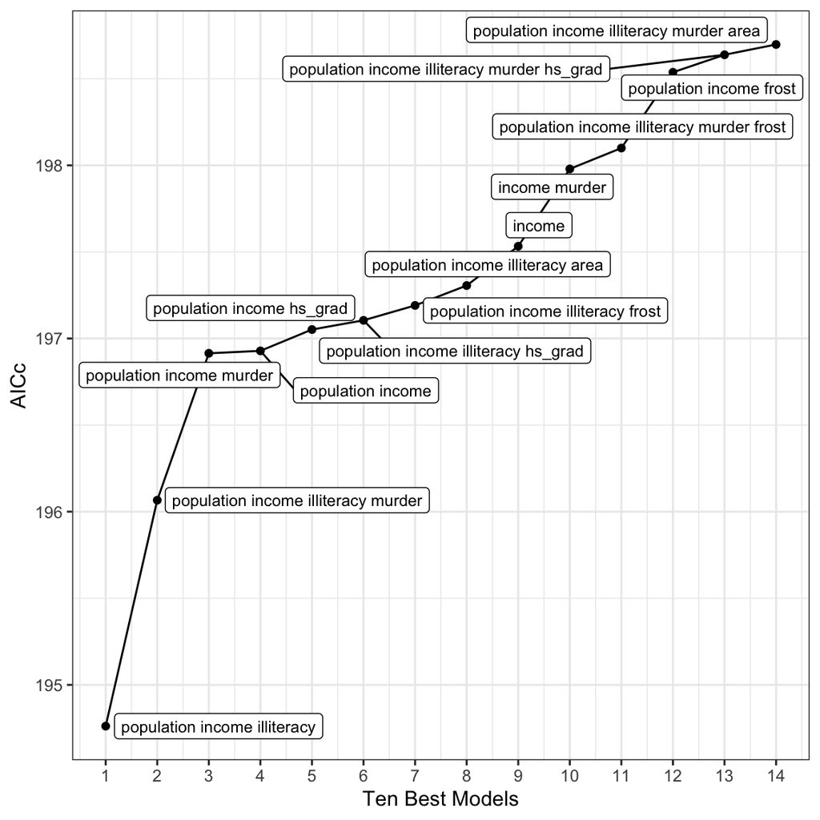

Figure 2: Fourteen plausible models and their predictors based on their AICc values.

```r
# Get models within 4 of minimum AICc
plausible = models |>
  select(mindex, n, predictors, aic_c) |>
  filter(aic_c - min(aic_c) < 4) |>
  arrange(aic_c)

# Load library for labeling
library(ggrepel)

# Plot the models
ggplot(data = plausible, aes(x = as.numeric(rownames(plausible)), y = aic_c)) +
  geom_line(group = 1) +
  geom_point() +
  geom_label_repel(aes(label = predictors), size = 3) +
  theme_bw() +
  scale_x_continuous(name = "Ten Best Models", breaks = 1:14) +
  ylab("AICc")
```

The models with the lowest AICc values all seem to include population and income. Many also include illiteracy rate.

## 99 Problems…

Automated methods of model selection has a host of critics and issues. In simulation studies, even when the true set of predictors are included in the subset of regression models, automated strategies may not identify these true predictors in the best models (Miller, 2002). The essential problems with automated selection methods have been summarized by Harrell (2001):

- $R^2$ values are biased high;
- The *F*-statistics are not *F*-distributed;
- The standard errors of the parameter estimates are too small;
  - Consequently, the confidence intervals around the parameter estimates are too narrow.
- *p*-values are too low, due to multiple comparisons, and are diﬃcult to correct;
- Parameter estimates are biased away from 0; and
- Collinearity problems are exacerbated.

In sum, the parameter estimates are likely to be too far away from zero; the variance estimates for those parameter estimates are not correct; which implies that the confidence intervals and hypothesis tests will be wrong; and there are no reasonable ways of correcting these problems! In general the evidence around using automated selection methods is that these methods are subpar. If you need to use these methods backward elimination seems to be the best method to use. (Stepwise regression consistently performs the worst.) Also, information criteria (AIC, BIC) seems to be the best criterion when using these methods.

**SUMMATION OF AUTOMATED METHODS**

Flom (2018) writes, “Most devastatingly, it allows the analyst not to think. Put in another way, for a data analyst to use stepwise methods is equivalent to telling his or her boss that his or her salary should be cut.”

## Some Considerations in Model Selection

Diﬀerent model strategies, metrics of model performance, and criteria for model selection lead to diﬀerent “final” models.

Many statistical programs have functionality that can automate these fitting strategies. Before automating the selection process, it is important to understand the purpose of your model (is it to describe the data? make predictions? inference?). This often guides the choice of performance metrics and model building strategy.

Although these packages can select a model based on some performance metric, there are several problems that automation does not solve:

- It does not address the functional form of the predictors.
- It does not address interactions.
- It does not address outliers.
- It does not address collinearity problems.

Most software will require that you deal with these problems sequentially; first selecting the variables for the model and then determining their functional form, interactons, etc.

## References

Flom, P. (2018). Stopping stepwise: Why stepwise selection is bad and what you should use instead. Towards data science. Retrieved from https://towardsdatascience.com/stopping-stepwise-why-stepwise-selection-is-bad-and-what-you-should-use-instead-90818b3f52df

Harrell, F. E. (2001). *Regression modeling strategies: With applications to linear models, logistic regression, and survival analysis*. Springer.

Miller, A. J. (2002). *Subset selection in regression*. Chapman & Hall.